# How’s The Weather?

Author

Jeremy Seebohm

Published

December 12, 2025

# Introduction

Welcome to this interactive technical manual created with Quarto. This document demonstrates professional hover-style tooltips for technical terms. Simply hover your mouse over any highlighted term to see an instant definition popup.

This manual integrates seamlessly with R code and analysis, making it perfect for technical reports and educational materials.

# Biochemistry Fundamentals

## Enzyme Function

An enzymeA biological catalyst that accelerates chemical reactions in living organisms without being consumed in the process is a specialized type of proteinA large biomolecule composed of amino acid chains that performs diverse functions in organisms, including catalysis, structure, and signaling that acts as a biological catalystA substance that increases the rate of a chemical reaction without undergoing permanent chemical change itself. Each enzymeA biological catalyst that accelerates chemical reactions in living organisms without being consumed in the process contains an active siteThe specific region of an enzyme where substrate molecules bind and undergo a chemical reaction where the substrateThe molecule upon which an enzyme acts, binding to the active site to undergo chemical transformation binds.

The enzymeA biological catalyst that accelerates chemical reactions in living organisms without being consumed in the process reduces the activation energy required for the reaction, allowing biological processes to occur at physiologically relevant rates.

## Energy Currency

Cells store energy in molecules like ATPAdenosine triphosphate - the primary energy currency of cells, storing and transferring energy for cellular processes, which powers most cellular work.

## Example with R Code

Here’s a simple calculation related to enzyme kinetics:

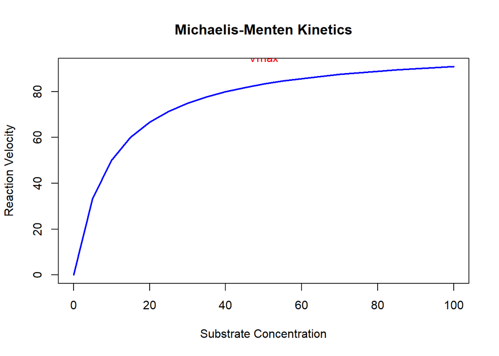

Michaelis-Menten Kinetics

```r
# Michaelis-Menten parameters
Vmax <- 100  # Maximum reaction velocity
Km <- 10     # Michaelis constant

# Substrate concentrations
substrate <- seq(0, 100, by = 5)

# Calculate reaction velocity
velocity <- (Vmax * substrate) / (Km + substrate)

# Plot
plot(substrate, velocity, type = "l", col = "blue", lwd = 2,
     xlab = "Substrate Concentration",
     ylab = "Reaction Velocity",
     main = "Michaelis-Menten Kinetics")
abline(h = Vmax, col = "red", lty = 2)
text(50, Vmax - 5, "Vmax", col = "red")
```

The curve shows how enzymeA biological catalyst that accelerates chemical reactions in living organisms without being consumed in the process velocity depends on substrateThe molecule upon which an enzyme acts, binding to the active site to undergo chemical transformation concentration.

# Computer Science Principles

## Algorithm Design

An algorithmA step-by-step procedure or formula for solving a problem or completing a task is a precise sequence of instructions for solving a problem. One powerful technique is recursionA programming technique where a function calls itself to solve smaller instances of the same problem, where an algorithmA step-by-step procedure or formula for solving a problem or completing a task calls itself with modified parameters.

Efficient algorithmsA step-by-step procedure or formula for solving a problem or completing a task often rely on optimal data structuresA specialized format for organizing, processing, and storing data in computer memory to achieve fast execution times.

## Example: Fibonacci with Recursion

```r
# Recursive implementation
fibonacci_recursive <- function(n) {
  if (n <= 1) return(n)
  return(fibonacci_recursive(n-1) + fibonacci_recursive(n-2))
}

# Calculate first 10 Fibonacci numbers
fib_numbers <- sapply(0:10, fibonacci_recursive)
print(fib_numbers)
```

```
 [1]  0  1  1  2  3  5  8 13 21 34 55
```

This demonstrates recursionA programming technique where a function calls itself to solve smaller instances of the same problem in action - the function calls itself to solve the problem.

# Thermodynamics and Mechanics

## Energy and Disorder

The second law of thermodynamics states that entropyA measure of disorder or randomness in a system; in thermodynamics, it quantifies the amount of thermal energy unavailable for work tends to increase in isolated systems. This principle explains why processes have preferred directions and why perfect efficiency is impossible.

## Motion and Conservation

When an object moves, it possesses momentumThe product of an object’s mass and velocity, representing its quantity of motion, which is conserved in closed systems.

```r
# Example: Two objects colliding
m1 <- 5  # mass 1 (kg)
v1 <- 10 # velocity 1 (m/s)
m2 <- 3  # mass 2 (kg)
v2 <- -5 # velocity 2 (m/s, negative = opposite direction)

# Total momentum before collision
momentum_before <- m1 * v1 + m2 * v2

cat("Total momentum before collision:", momentum_before, "kg·m/s\n")
```

```
Total momentum before collision: 35 kg·m/s
```

The conservation of momentumThe product of an object’s mass and velocity, representing its quantity of motion is fundamental to understanding collisions.

# How to Add New Terms

Adding your own glossary terms is simple! Follow these three steps:

## Step 1: Define in Setup Chunk

Add your definition variable to the setup chunk at the top of the document (after the other definitions):

```r
photosynthesis_def <- "The process by which plants convert light energy into chemical energy"
```

## Step 2: Use in Text

Then use the `glossary()` function in your text. Here’s a real working example:

Plants use photosynthesisThe process by which plants convert light energy into chemical energy to produce glucose and oxygen from sunlight, water, and carbon dioxide.

See how the term appears with a hover tooltip? You can either: - Define the term inline: `glossary("term", "definition here")` - Use a pre-defined variable: `glossary("term", term_def)`

## Step 3: Add to Complete Glossary

Add a corresponding entry in the “Complete Glossary” section at the bottom so readers can find all terms in one place.

# Complete Glossary

### All Technical Terms

**Active Site**  
The specific region of an enzyme where substrate molecules bind and undergo a chemical reaction.

**Algorithm**  
A step-by-step procedure or formula for solving a problem or completing a task.

**ATP (Adenosine Triphosphate)**  
The primary energy currency of cells, storing and transferring energy for cellular processes.

**Catalyst**  
A substance that increases the rate of a chemical reaction without undergoing permanent chemical change itself.

**Data Structure**  
A specialized format for organizing, processing, and storing data in computer memory.

**Entropy**  
A measure of disorder or randomness in a system; in thermodynamics, it quantifies the amount of thermal energy unavailable for work.

**Enzyme**  
A biological catalyst that accelerates chemical reactions in living organisms without being consumed in the process.

**Momentum**  
The product of an object’s mass and velocity, representing its quantity of motion.

**Protein**  
A large biomolecule composed of amino acid chains that performs diverse functions in organisms, including catalysis, structure, and signaling.

**Recursion**  
A programming technique where a function calls itself to solve smaller instances of the same problem.

**Substrate**  
The molecule upon which an enzyme acts, binding to the active site to undergo chemical transformation.